# Question

*S-IC.A.2: Decide if a specified model is consistent with results from a given data-generating process, e.g., using simulation.*

In [table-top role-playing games](https://en.wikipedia.org/wiki/Tabletop_role-playing_game), it is common to use [dice notation](https://en.wikipedia.org/wiki/Dice_notation). As an example, if a spell deals 15d20 damage, the player will roll fifteen 20-sided dice (where each die follows a [discrete uniform distribution](https://en.wikipedia.org/wiki/Discrete_uniform_distribution) between 1 and 20) and add all the pips.

Please use a spreadsheet to simulate 1000 repetitions of 15d20. From the simulation, determine an interval of typical totals (the boundaries of the middle 95% of results, at the 2.5th percentile and 97.5th percentile) and a margin of error (half the width of the interval). You might find [this guide](https://chadworley.github.io/a2/u01/p09_dice_sim.html) helpful.

Your values might differ slightly from the options; pick the closest.

- Lower boundary of interval of typical totals = ##ANSWER1##
- Upper boundary of interval of typical totals = ##ANSWER2##
- Margin of error = ##ANSWER3##

Now, as a statistician, you’ve decided that another player’s collection of fifteen 20-sided dice look suspicious. You decide to run a quick test by rolling them all. You decide ahead of time that if the total is inside the interval you will stay quiet. However, if the total is outside the interval, you will shout “guilty!”

When you roll them, you get a total of 185. What do you do? ##ANSWER4##

## Answerlist

- 101
- 114
- 127
- 140
- 189
- 202
- 215
- 228
- 18
- 31
- 44
- 57
- Stay quiet.
- Shout “guilty!”

# Solution

- Lower boundary = 114
- Upper boundary = 202
- Margin of error = 44
- Response = stay quiet.

It will be helpful to reference [this guide](https://chadworley.github.io/a2/u02/p09_dice_sim.html).

- Open a [new sheet](https://sheets.new).
- To simulate a roll of a 20-sided die, use `=RANDBETWEEN(1,20)`.
- Copy the formula to all cells in range A1:O1000. Each row has 15 rolls.
- In cell Q1, write `=sum(A1:O1)` to get the total of the first row.
- Drag the formula in Q1 down through Q1000 to get totals for each row.
- Freeze the simulation by using `ctrl+a` then `ctrl+c` then `ctrl+shift+v`.
- Sort the sheet by column Q (Click column Q, click Data > Sort sheet).
- In the sorted totals, find the 25th value and the 975th value. Those are the lower and upper boundaries.
- Subtract the values and divide by two. The result is the margin of error.
- If the observed total is within the boundaries, stay quiet. Otherwise shout “guilt!”

Here is a dot plot of my simulation.

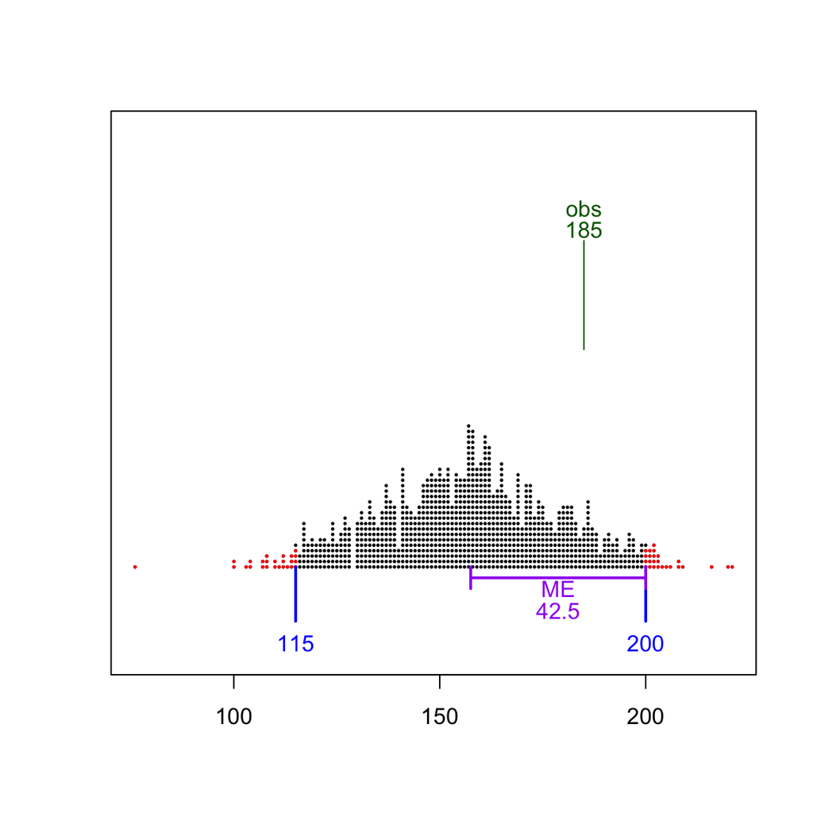

Notice the observation is in the interval of typical totals. That’s why you stay quiet.

# Meta-information

extype: cloze exclozetype: schoice|schoice|schoice|schoice exsolution: 0100|0100|0010|10 exname: dice_sim